# Data Summarization and Preprocessing

##### Phase 2 of Data Mining (IT 326) Project

The “Startup Success Prediction” dataset provides a comprehensive record of startup companies, tracing their early-stage decisions, such as funding rounds, categories, and more, spanning the years from 1984 to 2010. Notably, the ‘status’ attribute serves as a vital indicator, shedding light on the outcome of these decisions, distinguishing between productive outcomes, often leading to company acquisitions, and less favorable results that resulted in business closures.

### Project Motivation

Our **motivation** in building this model is for it to act as a guiding beacon for investors. When the model predicts the success of a startup, it becomes an attractive investment opportunity, ensuring that investors see a return on their investment. Conversely, if a startup is showing signs of potential failure and closure, it prompts investors to explore alternative investments.

### Goal

In this project, our **goal** is to build a predictive model capable of predicting the potential success of startups. We aspire to utilize the insights gained from this model to test and predict the possible success of startups within the region.

#### Source

Access the dataset on Kaggle through the following link: https://www.kaggle.com/datasets/manishkc06/startup-success-prediction

## 1-General Information About the Dataset

[output not shown]

***VC** stands for Venture Capitalist. Which is a type of investor that invests the money of a venture capital firm into small startup companies.

****Angel** stands for Angel Investor Which is a type of investor that invests their personal money into small startup companies in exchange for a percentage in the company.

#### Installing necessary packages:

```r
install.packages("readxl")
install.packages("lubridate")
install.packages("scatterplot3d")
install.packages("dplyr")
install.packages("ggplot2")
install.packages("colorspace")
```

```r
library(readxl)
dataset <- read_excel("Original_StartupData.xlsx")
```

#### Sample of raw dataset and summary:

```r
View(dataset)
summary(dataset)
```

```
   Unnamed: 0      state_code           latitude       longitude         zip_code              id
 Min.   :   1.0   Length:923         Min.   :25.75   Min.   :-122.76   Length:923         Length:923
 1st Qu.: 283.5   Class :character   1st Qu.:37.39   1st Qu.:-122.20   Class :character   Class :character
 Median : 577.0   Mode  :character   Median :37.78   Median :-118.37   Mode  :character   Mode  :character
 Mean   : 572.3                      Mean   :38.52   Mean   :-103.54
 3rd Qu.: 866.5                      3rd Qu.:40.73   3rd Qu.: -77.21
 Max.   :1153.0                      Max.   :59.34   Max.   :  18.06

     city            Unnamed: 6            name               labels        founded_at         closed_at
 Length:923         Length:923         Length:923         Min.   :0.0000   Length:923         Length:923
 Class :character   Class :character   Class :character   1st Qu.:0.0000   Class :character   Class :character
 Mode  :character   Mode  :character   Mode  :character   Median :1.0000   Mode  :character   Mode  :character
                                                          Mean   :0.6468
                                                          3rd Qu.:1.0000
                                                          Max.   :1.0000

 first_funding_at   last_funding_at    age_first_funding_year age_last_funding_year age_first_milestone_year
 Length:923         Length:923         Min.   :-9.0466        Min.   :-9.047        Min.   :-14.170
 Class :character   Class :character   1st Qu.: 0.5767        1st Qu.: 1.670        1st Qu.:  1.000
 Mode  :character   Mode  :character   Median : 1.4466        Median : 3.529        Median :  2.521
                                       Mean   : 2.2356        Mean   : 3.931        Mean   :  3.055
                                       3rd Qu.: 3.5753        3rd Qu.: 5.560        3rd Qu.:  4.686
                                       Max.   :21.8959        Max.   :21.896        Max.   : 24.685
                                                                                    NA's   :152
 age_last_milestone_year relationships    funding_rounds   funding_total_usd     milestones    state_code.1
 Min.   :-7.005          Min.   : 0.000   Min.   : 1.000   Min.   :1.100e+04   Min.   :0.000   Length:923
 1st Qu.: 2.411          1st Qu.: 3.000   1st Qu.: 1.000   1st Qu.:2.725e+06   1st Qu.:1.000   Class :character
 Median : 4.477          Median : 5.000   Median : 2.000   Median :1.000e+07   Median :2.000   Mode  :character
 Mean   : 4.754          Mean   : 7.711   Mean   : 2.311   Mean   :2.542e+07   Mean   :1.842
 3rd Qu.: 6.753          3rd Qu.:10.000   3rd Qu.: 3.000   3rd Qu.:2.472e+07   3rd Qu.:3.000
 Max.   :24.685          Max.   :63.000   Max.   :10.000   Max.   :5.700e+09   Max.   :8.000
 NA's   :152
     is_CA            is_NY            is_MA             is_TX        is_otherstate   category_code       is_software
 Min.   :0.0000   Min.   :0.0000   Min.   :0.00000   Min.   :0.0000   Min.   :0.000   Length:923         Min.   :0.0000
 1st Qu.:0.0000   1st Qu.:0.0000   1st Qu.:0.00000   1st Qu.:0.0000   1st Qu.:0.000   Class :character   1st Qu.:0.0000
 Median :1.0000   Median :0.0000   Median :0.00000   Median :0.0000   Median :0.000   Mode  :character   Median :0.0000
 Mean   :0.5276   Mean   :0.1148   Mean   :0.08992   Mean   :0.0455   Mean   :0.221                      Mean   :0.1658
 3rd Qu.:1.0000   3rd Qu.:0.0000   3rd Qu.:0.00000   3rd Qu.:0.0000   3rd Qu.:0.000                      3rd Qu.:0.0000
 Max.   :1.0000   Max.   :1.0000   Max.   :1.00000   Max.   :1.0000   Max.   :1.000                      Max.   :1.0000

```

[output cut: 8 more lines]

```
 is_consulting     is_othercategory  object_id             has_VC         has_angel        has_roundA       has_roundB
 Min.   :0.00000   Min.   :0.0000   Length:923         Min.   :0.0000   Min.   :0.0000   Min.   :0.0000   Min.   :0.0000
 1st Qu.:0.00000   1st Qu.:0.0000   Class :character   1st Qu.:0.0000   1st Qu.:0.0000   1st Qu.:0.0000   1st Qu.:0.0000
 Median :0.00000   Median :0.0000   Mode  :character   Median :0.0000   Median :0.0000   Median :1.0000   Median :0.0000
 Mean   :0.00325   Mean   :0.3229                      Mean   :0.3261   Mean   :0.2546   Mean   :0.5081   Mean   :0.3922
 3rd Qu.:0.00000   3rd Qu.:1.0000                      3rd Qu.:1.0000   3rd Qu.:1.0000   3rd Qu.:1.0000   3rd Qu.:1.0000
 Max.   :1.00000   Max.   :1.0000                      Max.   :1.0000   Max.   :1.0000   Max.   :1.0000   Max.   :1.0000

   has_roundC       has_roundD      avg_participants   is_top500         status
 Min.   :0.0000   Min.   :0.00000   Min.   : 1.000   Min.   :0.0000   Length:923
 1st Qu.:0.0000   1st Qu.:0.00000   1st Qu.: 1.500   1st Qu.:1.0000   Class :character
 Median :0.0000   Median :0.00000   Median : 2.500   Median :1.0000   Mode  :character
 Mean   :0.2329   Mean   :0.09967   Mean   : 2.839   Mean   :0.8093
 3rd Qu.:0.0000   3rd Qu.:0.00000   3rd Qu.: 3.800   3rd Qu.:1.0000
 Max.   :1.0000   Max.   :1.00000   Max.   :16.000   Max.   :1.0000
```

## 2-Data Preprocessing

### 2.1-Data Cleaning:

To clean the data of the dataset, we are going to detect and remove outliers, fill in missing values, and replace negative values.

#### Missing Values

```r
is.na(dataset)
```

```
       Unnamed: 0 state_code latitude longitude zip_code    id  city Unnamed: 6  name labels founded_at closed_at
  [1,]      FALSE      FALSE    FALSE     FALSE    FALSE FALSE FALSE       TRUE FALSE  FALSE      FALSE      TRUE
  [2,]      FALSE      FALSE    FALSE     FALSE    FALSE FALSE FALSE       TRUE FALSE  FALSE      FALSE      TRUE
  [3,]      FALSE      FALSE    FALSE     FALSE    FALSE FALSE FALSE      FALSE FALSE  FALSE      FALSE      TRUE
  [4,]      FALSE      FALSE    FALSE     FALSE    FALSE FALSE FALSE      FALSE FALSE  FALSE      FALSE      TRUE
  [5,]      FALSE      FALSE    FALSE     FALSE    FALSE FALSE FALSE      FALSE FALSE  FALSE      FALSE     FALSE
  [6,]      FALSE      FALSE    FALSE     FALSE    FALSE FALSE FALSE      FALSE FALSE  FALSE      FALSE     FALSE
  [7,]      FALSE      FALSE    FALSE     FALSE    FALSE FALSE FALSE       TRUE FALSE  FALSE      FALSE      TRUE
  [8,]      FALSE      FALSE    FALSE     FALSE    FALSE FALSE FALSE       TRUE FALSE  FALSE      FALSE      TRUE
  [9,]      FALSE      FALSE    FALSE     FALSE    FALSE FALSE FALSE      FALSE FALSE  FALSE      FALSE      TRUE
 [10,]      FALSE      FALSE    FALSE     FALSE    FALSE FALSE FALSE       TRUE FALSE  FALSE      FALSE      TRUE
 [11,]      FALSE      FALSE    FALSE     FALSE    FALSE FALSE FALSE       TRUE FALSE  FALSE      FALSE      TRUE
 [12,]      FALSE      FALSE    FALSE     FALSE    FALSE FALSE FALSE       TRUE FALSE  FALSE      FALSE     FALSE
 [13,]      FALSE      FALSE    FALSE     FALSE    FALSE FALSE FALSE       TRUE FALSE  FALSE      FALSE     FALSE
 [14,]      FALSE      FALSE    FALSE     FALSE    FALSE FALSE FALSE       TRUE FALSE  FALSE      FALSE      TRUE
```

[output cut: 112 more lines]

```r
sum(is.na(dataset))
```

```
[1] 1386
```

As demonstrated, **only four attributes contain missing values: Unnamed: 6, closed_at, age_first_milestone_year, and age_last_milestone_year**. From the four attributes, there are **1386 missing values** we are going to deal with.

For **attribute Unnamed: 6**, we will not fill it with any values as it will be deleted later in the data reduction step.

As for **attribute closed_at**, we will fill all missing values with the global constant N/A because information about the operation of the company (whether is is still open or closed) remains unknown.

```r
dataset$closed_at[is.na(dataset$closed_at)] <- "N/A"
```

Finally, for **attributes age_first_milestone_year and age_last_milestone_year** we will replace missing values with the attribute’s mean.

```r
dataset$age_first_milestone_year = ifelse (is.na(dataset$age_first_milestone_year), ave(dataset$age_first_milestone_year, FUN=function(x)mean(x,na.rm=TRUE)), dataset$age_first_milestone_year)

dataset$age_last_milestone_year = ifelse (is.na(dataset$age_last_milestone_year), ave(dataset$age_last_milestone_year, FUN=function(x)mean(x,na.rm=TRUE)), dataset$age_last_milestone_year)
```

#### Negative values

Negative values in attributes related to age do not make sense. So, we are going to change all negative values to positive.

```r
# Remove the negative sign from age_first_funding_year
dataset$age_first_funding_year <- abs(dataset$age_first_funding_year)

# Remove the negative sign from age_last_funding_year
dataset$age_last_funding_year <- abs(dataset$age_last_funding_year)

# Remove the negative sign from age_first_milestone_year
dataset$age_first_milestone_year <- abs(dataset$age_first_milestone_year)

# Remove the negative sign from age_last_milestone_year
dataset$age_last_milestone_year <- abs(dataset$age_last_milestone_year)
```

#### Outliers

We will detect outliers in all numerical attributes and remove them.

```r
install.packages("outliers")
library(outliers)
```

##### Sample of scatter plot before removing outliers from attribute age_first_milestone_year:

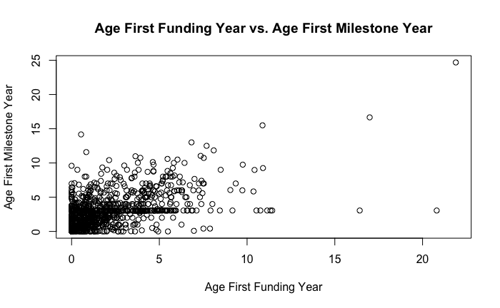

```r
plot(dataset$age_first_funding_year, dataset$age_first_milestone_year,
     main="Age First Funding Year vs. Age First Milestone Year",
     xlab = "Age First Funding Year",
     ylab = "Age First Milestone Year")
```

```r
## age_first_funding_year

# Calculate the quartiles
Q1 <- quantile(dataset$age_first_funding_year, 0.25)
Q3 <- quantile(dataset$age_first_funding_year, 0.75)

# Calculate the IQR
IQR <- Q3 - Q1

# Define the lower and upper bounds for outliers
lower_bound <- Q1 - 1.5 * IQR
upper_bound <- Q3 + 1.5 * IQR

# Remove outliers from the dataset using dplyr
library(dplyr)
dataset_clean1 <- dataset %>%
  filter(age_first_funding_year >= lower_bound, age_first_funding_year <= upper_bound)

# Print the dimensions of the cleaned dataset
cat("funding_total_usd","\n")
```

```
funding_total_usd
```

```r
cat("Original dataset dimensions: ", dim(dataset), "\n")
```

```
Original dataset dimensions:  923 49
```

```r
cat("Cleaned dataset dimensions: ", dim(dataset_clean1), "\n","\n")
```

```
Cleaned dataset dimensions:  902 49
```

```r
dataset <- dataset_clean1

#################################
## age_last_funding_year

Q1 <- quantile(dataset$age_last_funding_year, 0.25)
Q3 <- quantile(dataset$age_last_funding_year, 0.75)
IQR <- Q3 - Q1
lower_bound <- Q1 - 1.5 * IQR
upper_bound <- Q3 + 1.5 * IQR
library(dplyr)
dataset_clean2 <- dataset %>%
  filter(age_last_funding_year >= lower_bound, age_last_funding_year <= upper_bound)

cat("age_last_funding_year","\n")
```

```
age_last_funding_year
```

```r
cat("Original dataset dimensions: ", dim(dataset), "\n")
```

```
Original dataset dimensions:  902 49
```

```r
cat("Cleaned dataset dimensions: ", dim(dataset_clean2), "\n","\n")
```

```
Cleaned dataset dimensions:  895 49
```

```r
dataset <- dataset_clean2

#################################
## age_first_milestone_year

Q1 <- quantile(dataset$age_first_milestone_year, 0.25)
Q3 <- quantile(dataset$age_first_milestone_year, 0.75)
IQR <- Q3 - Q1
lower_bound <- Q1 - 1.5 * IQR
upper_bound <- Q3 + 1.5 * IQR
library(dplyr)
dataset_clean3 <- dataset %>%
  filter(age_first_milestone_year >= lower_bound, age_first_milestone_year <= upper_bound)

cat("age_first_milestone_year","\n")
```

```
age_first_milestone_year
```

```r
cat("Original dataset dimensions: ", dim(dataset), "\n")
```

```
Original dataset dimensions:  895 49
```

```r
cat("Cleaned dataset dimensions: ", dim(dataset_clean3), "\n","\n")
```

```
Cleaned dataset dimensions:  864 49
```

```r
dataset <- dataset_clean3

#################################
## age_last_milestone_year

Q1 <- quantile(dataset$age_last_milestone_year, 0.25)
Q3 <- quantile(dataset$age_last_milestone_year, 0.75)
IQR <- Q3 - Q1
lower_bound <- Q1 - 1.5 * IQR
upper_bound <- Q3 + 1.5 * IQR
library(dplyr)
dataset_clean4 <- dataset %>%
  filter(age_last_milestone_year >= lower_bound, age_last_milestone_year <= upper_bound)

cat("age_last_milestone_year","\n")
```

```
age_last_milestone_year
```

```r
cat("Original dataset dimensions: ", dim(dataset), "\n")
```

```
Original dataset dimensions:  864 49
```

```r
cat("Cleaned dataset dimensions: ", dim(dataset_clean4), "\n","\n")
```

```
Cleaned dataset dimensions:  845 49
```

```r
dataset <- dataset_clean4

#################################
## relationships

Q1 <- quantile(dataset$relationships, 0.25)
Q3 <- quantile(dataset$relationships, 0.75)
IQR <- Q3 - Q1
lower_bound <- Q1 - 1.5 * IQR
upper_bound <- Q3 + 1.5 * IQR
library(dplyr)
dataset_clean5 <- dataset %>%
  filter(relationships >= lower_bound, relationships <= upper_bound)

cat("relationships","\n")
```

```
relationships
```

```r
cat("Original dataset dimensions: ", dim(dataset), "\n")
```

```
Original dataset dimensions:  845 49
```

```r
cat("Cleaned dataset dimensions: ", dim(dataset_clean5), "\n","\n")
```

```
Cleaned dataset dimensions:  795 49
```

```r
dataset <- dataset_clean5

#################################
## funding_rounds

Q1 <- quantile(dataset$funding_rounds, 0.25)
Q3 <- quantile(dataset$funding_rounds, 0.75)
IQR <- Q3 - Q1
lower_bound <- Q1 - 1.5 * IQR
upper_bound <- Q3 + 1.5 * IQR
library(dplyr)
dataset_clean6 <- dataset %>%
  filter(funding_rounds >= lower_bound, funding_rounds <= upper_bound)

cat("funding_rounds","\n")
```

```
funding_rounds
```

```r
cat("Original dataset dimensions: ", dim(dataset), "\n")
```

```
Original dataset dimensions:  795 49
```

```r
cat("Cleaned dataset dimensions: ", dim(dataset_clean6), "\n","\n")
```

```
Cleaned dataset dimensions:  786 49
```

```r
dataset <- dataset_clean6

#################################
## funding_total_usd

Q1 <- quantile(dataset$funding_total_usd, 0.25)
Q3 <- quantile(dataset$funding_total_usd, 0.75)
IQR <- Q3 - Q1
lower_bound <- Q1 - 1.5 * IQR
upper_bound <- Q3 + 1.5 * IQR
library(dplyr)
dataset_clean7 <- dataset %>%
  filter(funding_total_usd >= lower_bound, funding_total_usd <= upper_bound)

cat("funding_total_usd","\n")
```

```
funding_total_usd
```

```r
cat("Original dataset dimensions: ", dim(dataset), "\n")
```

```
Original dataset dimensions:  786 49
```

```r
cat("Cleaned dataset dimensions: ", dim(dataset_clean7), "\n","\n")
```

```
Cleaned dataset dimensions:  727 49
```

```r
dataset <- dataset_clean7

#################################
## milestones

Q1 <- quantile(dataset$milestones, 0.25)
Q3 <- quantile(dataset$milestones, 0.75)
IQR <- Q3 - Q1
lower_bound <- Q1 - 1.5 * IQR
upper_bound <- Q3 + 1.5 * IQR
library(dplyr)
dataset_clean8 <- dataset %>%
  filter(milestones >= lower_bound, milestones <= upper_bound)

cat("milestones","\n")
```

```
milestones
```

```r
cat("Original dataset dimensions: ", dim(dataset), "\n")
```

```
Original dataset dimensions:  727 49
```

```r
cat("Cleaned dataset dimensions: ", dim(dataset_clean8), "\n","\n")
```

```
Cleaned dataset dimensions:  727 49
```

```r
dataset <- dataset_clean8
```

##### Sample of scatter plot after removing outliers from attribute age_first_milestone_year:

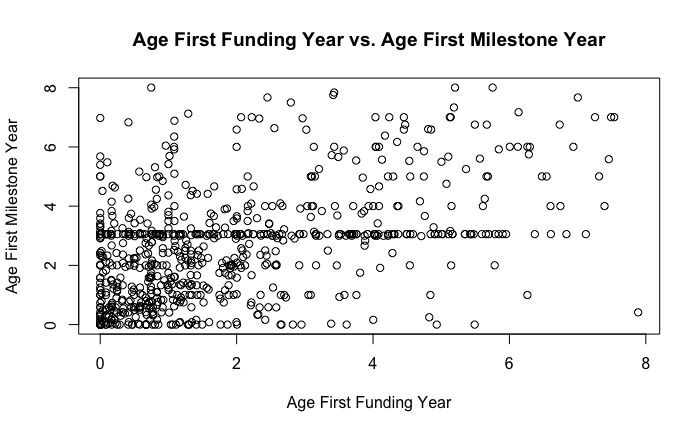

```r
plot(dataset$age_first_funding_year, dataset$age_first_milestone_year,
     main="Age First Funding Year vs. Age First Milestone Year",
     xlab = "Age First Funding Year",
     ylab = "Age First Milestone Year")
```

Attributes **latitude** and **longitude** will be removed in the data reduction step. Therefore, it will be unnecessary to detect their outliers.

### 2.2-Data Integration:

```r
contingency_table <- table(dataset$zip_code, dataset$city)
chi_square_result <- chisq.test(contingency_table)
print(chi_square_result)
```

```
    Pearson's Chi-squared test

data:  contingency_table
X-squared = 128324, df = 57905, p-value < 2.2e-16
```

With the results above, we can interpret that zip_code and city have a **significance correlation** between them. In other words, **they are not independent (dependent) and we can eliminate one of them**. We chose to delete zip_code and keep city. Because city constitutes a part of attribute Unnammed: 6, and if we want to delete column Unnamed: 6 we must keep city.

### 2.3-Data Reduction:

#### Dimensionality Reduction: Attribute Subset Selection

From the data integration step, we can infer that the **attributes to remove are:**

| Attribute(s) | Keep | Remove | Why |
| --- | --- | --- | --- |
| state_code, state_code.1 | state_code.1 | state_code | Duplicate attribute |
| latitude | N/A | latitude | Irrelevant |
| longitude | N/A | longitude | Irrelevant |
| zip_code, city | city | zip_code | Dependent attributes (chi-square test) |
| id | N/A | id | Irrelevant and unclear |
| Unnamed:6, city, state_code.1 | city, state_code.1 | Unnamed:6 | Redundant attribute |
| object_id | N/A | object_id | Irrelevant and unclear |

```r
# Create a list of column names to remove
columns_to_remove <- c("state_code", "latitude", "longitude", "zip_code", "id", "Unnamed: 6", "object_id")

# Remove the specified columns from the dataset
dataset <- dataset[, !names(dataset) %in% columns_to_remove]

# View the updated dataset
head(dataset)
```

| Unnamed: 0 | city | name | labels | founded_at | closed_at | first_funding_at | last_funding_at | age_first_funding_year | age_last_funding_year | age_first_milestone_year | age_last_milestone_year | relationships | funding_rounds | funding_total_usd | milestones | state_code.1 | is_CA | is_NY | is_MA | is_TX | is_otherstate | category_code | is_software | is_web | is_mobile | is_enterprise | is_advertising | is_gamesvideo | is_ecommerce | … |
| --- | --- | --- | --- | --- | --- | --- | --- | --- | --- | --- | --- | --- | --- | --- | --- | --- | --- | --- | --- | --- | --- | --- | --- | --- | --- | --- | --- | --- | --- | --- |
| 1005 | San Diego | Bandsintown | 1 | 1/1/2007 | N/A | 4/1/2009 | 1/1/2010 | 2.2493 | 3.0027 | 4.6685 | 6.7041 | 3 | 3 | 375000 | 3 | CA | 1 | 0 | 0 | 0 | 0 | music | 0 | 0 | 0 | 0 | 0 | 0 | 0 | … |
| 204 | Los Gatos | TriCipher | 1 | 1/1/2000 | N/A | 2/14/2005 | 12/28/2009 | 5.1260 | 9.9973 | 7.0055 | 7.0055 | 9 | 4 | 40100000 | 1 | CA | 1 | 0 | 0 | 0 | 0 | enterprise | 0 | 0 | 0 | 1 | 0 | 0 | 0 | … |
| 1001 | San Diego | Plixi | 1 | 3/18/2009 | N/A | 3/30/2010 | 3/30/2010 | 1.0329 | 1.0329 | 1.4575 | 2.2055 | 5 | 1 | 2600000 | 2 | CA | 1 | 0 | 0 | 0 | 0 | web | 0 | 1 | 0 | 0 | 0 | 0 | 0 | … |
| 738 | Cupertino | Solidcore Systems | 1 | 1/1/2002 | N/A | 2/17/2005 | 4/25/2007 | 3.1315 | 5.3151 | 6.0027 | 6.0027 | 5 | 3 | 40000000 | 1 | CA | 1 | 0 | 0 | 0 | 0 | software | 1 | 0 | 0 | 0 | 0 | 0 | 0 | … |
| 1002 | San Francisco | Inhale Digital | 0 | 8/1/2010 | 10/1/2012 | 8/1/2010 | 4/1/2012 | 0.0000 | 1.6685 | 0.0384 | 0.0384 | 2 | 2 | 1300000 | 1 | CA | 1 | 0 | 0 | 0 | 0 | games_video | 0 | 0 | 0 | 0 | 0 | 1 | 0 | … |
| 379 | Mountain View | Matisse Networks | 0 | 1/1/2002 | 2/15/2009 | 7/18/2006 | 7/18/2006 | 4.5452 | 4.5452 | 5.0027 | 5.0027 | 3 | 1 | 7500000 | 1 | CA | 1 | 0 | 0 | 0 | 0 | network_hosting | 0 | 0 | 0 | 0 | 0 | 0 | 0 | … |

```r
ncol(dataset)
```

```
[1] 42
```

```r
nrow(dataset)
```

```
[1] 727
```

### 2.4-Data Transformation:

#### Normalization

Normalize attributes: funding_total_usd, age_first_funding, age_last_funding, age_first_milestone, age_last_milestone, avg_participants into discrete numbers (remove all numbers after the decimal).

```r
normalize <- function(x) {return(as.integer(x))}

dataset$funding_total_usd <- normalize(dataset$funding_total_usd)
dataset$age_first_funding_year <- normalize(dataset$age_first_funding_year)
dataset$age_last_funding_year <- normalize(dataset$age_last_funding_year)
dataset$age_first_milestone_year <- normalize(dataset$age_first_milestone_year)
dataset$age_last_milestone_year <- normalize(dataset$age_last_milestone_year)
dataset$avg_participants <- normalize(dataset$avg_participants)
```

```r
normalize <- function(x) {return ((x - min(x)) / (max(x) - min(x)))}
dataset$funding_total_usd<-normalize(dataset$funding_total_usd)
head(dataset)
```

| Unnamed: 0 | city | name | labels | founded_at | closed_at | first_funding_at | last_funding_at | age_first_funding_year | age_last_funding_year | age_first_milestone_year | age_last_milestone_year | relationships | funding_rounds | funding_total_usd | milestones | state_code.1 | is_CA | is_NY | is_MA | is_TX | is_otherstate | category_code | is_software | is_web | is_mobile | is_enterprise | is_advertising | is_gamesvideo | is_ecommerce | … |
| --- | --- | --- | --- | --- | --- | --- | --- | --- | --- | --- | --- | --- | --- | --- | --- | --- | --- | --- | --- | --- | --- | --- | --- | --- | --- | --- | --- | --- | --- | --- |
| 1005 | San Diego | Bandsintown | 1 | 1/1/2007 | N/A | 4/1/2009 | 1/1/2010 | 2 | 3 | 4 | 6 | 3 | 3 | 0.00771064 | 3 | CA | 1 | 0 | 0 | 0 | 0 | music | 0 | 0 | 0 | 0 | 0 | 0 | 0 | … |
| 204 | Los Gatos | TriCipher | 1 | 1/1/2000 | N/A | 2/14/2005 | 12/28/2009 | 5 | 9 | 7 | 7 | 9 | 4 | 0.84920832 | 1 | CA | 1 | 0 | 0 | 0 | 0 | enterprise | 0 | 0 | 0 | 1 | 0 | 0 | 0 | … |
| 1001 | San Diego | Plixi | 1 | 3/18/2009 | N/A | 3/30/2010 | 3/30/2010 | 1 | 1 | 1 | 2 | 5 | 1 | 0.05484298 | 2 | CA | 1 | 0 | 0 | 0 | 0 | web | 0 | 1 | 0 | 0 | 0 | 0 | 0 | … |
| 738 | Cupertino | Solidcore Systems | 1 | 1/1/2002 | N/A | 2/17/2005 | 4/25/2007 | 3 | 5 | 6 | 6 | 5 | 3 | 0.84709001 | 1 | CA | 1 | 0 | 0 | 0 | 0 | software | 1 | 0 | 0 | 0 | 0 | 0 | 0 | … |
| 1002 | San Francisco | Inhale Digital | 0 | 8/1/2010 | 10/1/2012 | 8/1/2010 | 4/1/2012 | 0 | 1 | 0 | 0 | 2 | 2 | 0.02730498 | 1 | CA | 1 | 0 | 0 | 0 | 0 | games_video | 0 | 0 | 0 | 0 | 0 | 1 | 0 | … |
| 379 | Mountain View | Matisse Networks | 0 | 1/1/2002 | 2/15/2009 | 7/18/2006 | 7/18/2006 | 4 | 4 | 5 | 5 | 3 | 1 | 0.15864005 | 1 | CA | 1 | 0 | 0 | 0 | 0 | network_hosting | 0 | 0 | 0 | 0 | 0 | 0 | 0 | … |

#### Aggregation

Aggregate attributes: founded_at, closed_at, first_funding_at, last_funding_at into ( mm-yyyy ) format.

```r
library(lubridate)
dataset$founded_at <- as.Date(dataset$founded_at, format = "%m/%d/%Y")
dataset$closed_at <- as.Date(dataset$closed_at, format = "%m/%d/%Y")
dataset$first_funding_at <- as.Date(dataset$first_funding_at, format = "%m/%d/%Y")
dataset$last_funding_at <- as.Date(dataset$last_funding_at, format = "%m/%d/%Y")

dataset$founded_at <- format(dataset$founded_at, "%m-%Y")
dataset$closed_at <- format(dataset$closed_at, "%m-%Y")
dataset$first_funding_at <- format(dataset$first_funding_at, "%m-%Y")
dataset$last_funding_at <- format(dataset$last_funding_at, "%m-%Y")
```

```r
# View the updated dataset
tail(dataset)
```

| Unnamed: 0 | city | name | labels | founded_at | closed_at | first_funding_at | last_funding_at | age_first_funding_year | age_last_funding_year | age_first_milestone_year | age_last_milestone_year | relationships | funding_rounds | funding_total_usd | milestones | state_code.1 | is_CA | is_NY | is_MA | is_TX | is_otherstate | category_code | is_software | is_web | is_mobile | is_enterprise | is_advertising | is_gamesvideo | is_ecommerce | … |
| --- | --- | --- | --- | --- | --- | --- | --- | --- | --- | --- | --- | --- | --- | --- | --- | --- | --- | --- | --- | --- | --- | --- | --- | --- | --- | --- | --- | --- | --- | --- |
| 879 | New York | Panvidea | 1 | 01-2007 | NA | 03-2010 | 03-2010 | 3 | 3 | 3 | 4 | 5 | 1 | 0.05696129 | 2 | NY | 0 | 1 | 0 | 0 | 0 | games_video | 0 | 0 | 0 | 0 | 0 | 1 | 0 | … |
| 228 | Middleton | Sway | 0 | 12-2004 | 12-2012 | 01-2010 | 01-2010 | 5 | 5 | 3 | 8 | 6 | 1 | 0.04213314 | 2 | WI | 0 | 0 | 0 | 0 | 1 | advertising | 0 | 0 | 0 | 0 | 1 | 0 | 0 | … |
| 284 | New York | TRAFFIQ | 1 | 09-2006 | NA | 09-2006 | 08-2010 | 0 | 3 | 2 | 5 | 16 | 3 | 0.38106235 | 3 | NY | 0 | 1 | 0 | 0 | 0 | advertising | 0 | 0 | 0 | 0 | 1 | 0 | 0 | … |
| 352 | San Francisco | CoTweet | 1 | 01-2009 | NA | 07-2009 | 07-2009 | 0 | 0 | 0 | 4 | 9 | 1 | 0.02306837 | 2 | CA | 1 | 0 | 0 | 0 | 0 | advertising | 0 | 0 | 0 | 0 | 1 | 0 | 0 | … |
| 589 | San Francisco | Causata | 1 | 01-2009 | NA | 10-2009 | 11-2011 | 0 | 2 | 0 | 3 | 12 | 2 | 0.32810466 | 2 | CA | 1 | 0 | 0 | 0 | 0 | software | 1 | 0 | 0 | 0 | 0 | 0 | 0 | … |
| 462 | Santa Clara | Asempra Technologies | 1 | 01-2003 | NA | 02-2006 | 02-2006 | 3 | 3 | 4 | 4 | 4 | 1 | 0.42342850 | 1 | CA | 1 | 0 | 0 | 0 | 0 | security | 0 | 0 | 0 | 0 | 0 | 0 | 0 | … |

## 3-Data Summary & Visualization

### 3.1-Data Summary after preprocessing:

```r
# number of rows
nrow(dataset)
```

```
[1] 727
```

There are 727 rows in the dataset after preprocessing.

```r
#number of columns
ncol(dataset)
```

```
[1] 42
```

There are 42 columns in the dataset after preprocessing.

```r
# dimensionality
dim(dataset)
```

```
[1] 727  42
```

There are 727 rows and 42 columns in the dataset after preprocessing.

#### Column Names of Clean (Preprocessed) Dataset

```r
names(dataset)
```

```
 [1] "Unnamed: 0"               "city"                     "name"                     "labels"
 [5] "founded_at"               "closed_at"                "first_funding_at"         "last_funding_at"
 [9] "age_first_funding_year"   "age_last_funding_year"    "age_first_milestone_year" "age_last_milestone_year"
[13] "relationships"            "funding_rounds"           "funding_total_usd"        "milestones"
[17] "state_code.1"             "is_CA"                    "is_NY"                    "is_MA"
[21] "is_TX"                    "is_otherstate"            "category_code"            "is_software"
[25] "is_web"                   "is_mobile"                "is_enterprise"            "is_advertising"
[29] "is_gamesvideo"            "is_ecommerce"             "is_biotech"               "is_consulting"
[33] "is_othercategory"         "has_VC"                   "has_angel"                "has_roundA"
[37] "has_roundB"               "has_roundC"               "has_roundD"               "avg_participants"
[41] "is_top500"                "status"
```

#### Column Names of Original Dataset for Comparison

```r
# Load the readxl package if not already loaded
library(readxl)

# Read the Excel file into the 'OriginalDataset' variable
OriginalDataset <- read_excel("Original_StartupData.xlsx")

# Get the column names of the imported dataset
column_names <- names(OriginalDataset)

# Display the column names
print(column_names)
```

```
 [1] "Unnamed: 0"               "state_code"               "latitude"                 "longitude"
 [5] "zip_code"                 "id"                       "city"                     "Unnamed: 6"
 [9] "name"                     "labels"                   "founded_at"               "closed_at"
[13] "first_funding_at"         "last_funding_at"          "age_first_funding_year"   "age_last_funding_year"
[17] "age_first_milestone_year" "age_last_milestone_year"  "relationships"            "funding_rounds"
[21] "funding_total_usd"        "milestones"               "state_code.1"             "is_CA"
[25] "is_NY"                    "is_MA"                    "is_TX"                    "is_otherstate"
[29] "category_code"            "is_software"              "is_web"                   "is_mobile"
[33] "is_enterprise"            "is_advertising"           "is_gamesvideo"            "is_ecommerce"
[37] "is_biotech"               "is_consulting"            "is_othercategory"         "object_id"
[41] "has_VC"                   "has_angel"                "has_roundA"               "has_roundB"
[45] "has_roundC"               "has_roundD"               "avg_participants"         "is_top500"
[49] "status"
```

```r
# structure of dataset
str(dataset)
```

```
tibble [727 × 42] (S3: tbl_df/tbl/data.frame)
 $ Unnamed: 0              : num [1:727] 1005 204 1001 738 1002 ...
 $ city                    : chr [1:727] "San Diego" "Los Gatos" "San Diego" "Cupertino" ...
 $ name                    : chr [1:727] "Bandsintown" "TriCipher" "Plixi" "Solidcore Systems" ...
 $ labels                  : num [1:727] 1 1 1 1 0 0 1 1 0 0 ...
 $ founded_at              : chr [1:727] "01-2007" "01-2000" "03-2009" "01-2002" ...
 $ closed_at               : chr [1:727] NA NA NA NA ...
 $ first_funding_at        : chr [1:727] "04-2009" "02-2005" "03-2010" "02-2005" ...
 $ last_funding_at         : chr [1:727] "01-2010" "12-2009" "03-2010" "04-2007" ...
 $ age_first_funding_year  : int [1:727] 2 5 1 3 0 4 1 1 1 4 ...
 $ age_last_funding_year   : int [1:727] 3 9 1 5 1 4 5 4 5 4 ...
 $ age_first_milestone_year: int [1:727] 4 7 1 6 0 5 3 2 0 3 ...
 $ age_last_milestone_year : int [1:727] 6 7 2 6 0 5 6 6 4 4 ...
 $ relationships           : num [1:727] 3 9 5 5 2 3 6 14 8 0 ...
 $ funding_rounds          : num [1:727] 3 4 1 3 2 1 3 3 5 1 ...
```

[output cut: 28 more lines]

```r
# attributes of dataset
attributes(dataset)
```

```
$names
 [1] "Unnamed: 0"               "city"                     "name"                     "labels"
 [5] "founded_at"               "closed_at"                "first_funding_at"         "last_funding_at"
 [9] "age_first_funding_year"   "age_last_funding_year"    "age_first_milestone_year" "age_last_milestone_year"
[13] "relationships"            "funding_rounds"           "funding_total_usd"        "milestones"
[17] "state_code.1"             "is_CA"                    "is_NY"                    "is_MA"
[21] "is_TX"                    "is_otherstate"            "category_code"            "is_software"
[25] "is_web"                   "is_mobile"                "is_enterprise"            "is_advertising"
[29] "is_gamesvideo"            "is_ecommerce"             "is_biotech"               "is_consulting"
[33] "is_othercategory"         "has_VC"                   "has_angel"                "has_roundA"
[37] "has_roundB"               "has_roundC"               "has_roundD"               "avg_participants"
[41] "is_top500"                "status"

$row.names
  [1]   1   2   3   4   5   6   7   8   9  10  11  12  13  14  15  16  17  18  19  20  21  22  23  24  25  26  27  28  29  30
```

[output cut: 27 more lines]

#### Summary of Data

```r
summary(dataset)
```

```
   Unnamed: 0         city               name               labels        founded_at         closed_at
 Min.   :   2.0   Length:727         Length:727         Min.   :0.0000   Length:727         Length:727
 1st Qu.: 302.5   Class :character   Class :character   1st Qu.:0.0000   Class :character   Class :character
 Median : 608.0   Mode  :character   Mode  :character   Median :1.0000   Mode  :character   Mode  :character
 Mean   : 596.2                                         Mean   :0.6217
 3rd Qu.: 896.5                                         3rd Qu.:1.0000
 Max.   :1153.0                                         Max.   :1.0000
 first_funding_at   last_funding_at    age_first_funding_year age_last_funding_year age_first_milestone_year
 Length:727         Length:727         Min.   :0.000          Min.   : 0.000        Min.   :0.000
 Class :character   Class :character   1st Qu.:0.000          1st Qu.: 1.000        1st Qu.:1.000
 Mode  :character   Mode  :character   Median :1.000          Median : 2.000        Median :2.000
                                       Mean   :1.554          Mean   : 2.772        Mean   :2.329
                                       3rd Qu.:3.000          3rd Qu.: 4.000        3rd Qu.:3.000
                                       Max.   :7.000          Max.   :10.000        Max.   :8.000
 age_last_milestone_year relationships    funding_rounds  funding_total_usd   milestones    state_code.1
 Min.   : 0.000          Min.   : 0.000   Min.   :1.000   Min.   :0.00000   Min.   :0.000   Length:727
 1st Qu.: 2.000          1st Qu.: 3.000   1st Qu.:1.000   1st Qu.:0.04213   1st Qu.:1.000   Class :character
 Median : 4.000          Median : 5.000   Median :2.000   Median :0.14805   Median :2.000   Mode  :character
 Mean   : 3.675          Mean   : 6.149   Mean   :2.032   Mean   :0.22877   Mean   :1.754
 3rd Qu.: 5.000          3rd Qu.: 9.000   3rd Qu.:3.000   3rd Qu.:0.32879   3rd Qu.:3.000
 Max.   :10.000          Max.   :20.000   Max.   :6.000   Max.   :1.00000   Max.   :6.000
     is_CA            is_NY            is_MA             is_TX         is_otherstate   category_code       is_software
 Min.   :0.0000   Min.   :0.0000   Min.   :0.00000   Min.   :0.00000   Min.   :0.000   Length:727         Min.   :0.0000
 1st Qu.:0.0000   1st Qu.:0.0000   1st Qu.:0.00000   1st Qu.:0.00000   1st Qu.:0.000   Class :character   1st Qu.:0.0000
 Median :1.0000   Median :0.0000   Median :0.00000   Median :0.00000   Median :0.000   Mode  :character   Median :0.0000
 Mean   :0.5131   Mean   :0.1224   Mean   :0.08941   Mean   :0.04677   Mean   :0.227                      Mean   :0.1719
 3rd Qu.:1.0000   3rd Qu.:0.0000   3rd Qu.:0.00000   3rd Qu.:0.00000   3rd Qu.:0.000                      3rd Qu.:0.0000
 Max.   :1.0000   Max.   :1.0000   Max.   :1.00000   Max.   :1.00000   Max.   :1.000                      Max.   :1.0000
     is_web         is_mobile       is_enterprise     is_advertising    is_gamesvideo      is_ecommerce       is_biotech
 Min.   :0.0000   Min.   :0.00000   Min.   :0.00000   Min.   :0.00000   Min.   :0.00000   Min.   :0.00000   Min.   :0.00000
 1st Qu.:0.0000   1st Qu.:0.00000   1st Qu.:0.00000   1st Qu.:0.00000   1st Qu.:0.00000   1st Qu.:0.00000   1st Qu.:0.00000
 Median :0.0000   Median :0.00000   Median :0.00000   Median :0.00000   Median :0.00000   Median :0.00000   Median :0.00000
 Mean   :0.1637   Mean   :0.08391   Mean   :0.08391   Mean   :0.06602   Mean   :0.05777   Mean   :0.03026   Mean   :0.01788
 3rd Qu.:0.0000   3rd Qu.:0.00000   3rd Qu.:0.00000   3rd Qu.:0.00000   3rd Qu.:0.00000   3rd Qu.:0.00000   3rd Qu.:0.00000
 Max.   :1.0000   Max.   :1.00000   Max.   :1.00000   Max.   :1.00000   Max.   :1.00000   Max.   :1.00000   Max.   :1.00000
 is_consulting      is_othercategory     has_VC         has_angel        has_roundA       has_roundB      has_roundC
 Min.   :0.000000   Min.   :0.0000   Min.   :0.0000   Min.   :0.0000   Min.   :0.0000   Min.   :0.000   Min.   :0.0000
 1st Qu.:0.000000   1st Qu.:0.0000   1st Qu.:0.0000   1st Qu.:0.0000   1st Qu.:0.0000   1st Qu.:0.000   1st Qu.:0.0000
 Median :0.000000   Median :0.0000   Median :0.0000   Median :0.0000   Median :1.0000   Median :0.000   Median :0.0000
 Mean   :0.002751   Mean   :0.3219   Mean   :0.2889   Mean   :0.2861   Mean   :0.5021   Mean   :0.337   Mean   :0.1719
 3rd Qu.:0.000000   3rd Qu.:1.0000   3rd Qu.:1.0000   3rd Qu.:1.0000   3rd Qu.:1.0000   3rd Qu.:1.000   3rd Qu.:0.0000
 Max.   :1.000000   Max.   :1.0000   Max.   :1.0000   Max.   :1.0000   Max.   :1.0000   Max.   :1.000   Max.   :1.0000
   has_roundD      avg_participants   is_top500         status
 Min.   :0.00000   Min.   : 1.000   Min.   :0.0000   Length:727
 1st Qu.:0.00000   1st Qu.: 1.000   1st Qu.:1.0000   Class :character
 Median :0.00000   Median : 2.000   Median :1.0000   Mode  :character
 Mean   :0.04814   Mean   : 2.534   Mean   :0.7785
 3rd Qu.:0.00000   3rd Qu.: 3.000   3rd Qu.:1.0000
 Max.   :1.00000   Max.   :16.000   Max.   :1.0000
```

```r
library(Hmisc)
describe(dataset)
```

```
dataset

 42  Variables      727  Observations
-------------------------------------------------------------------------------------------------------------------------------
Unnamed: 0
       n  missing distinct     Info     Mean      Gmd      .05      .10      .25      .50      .75      .90      .95
     727        0      727        1    596.2    388.5     61.3    120.6    302.5    608.0    896.5   1034.8   1092.7

lowest :    2    3    4    5    7, highest: 1149 1150 1151 1152 1153
-------------------------------------------------------------------------------------------------------------------------------
city
       n  missing distinct
     727        0      186

lowest : Acton       Addison     Alameda     Albuquerque Aliso Viejo, highest: Woburn      Woodbury    Yardley     Yorba Linda Zeeland
-------------------------------------------------------------------------------------------------------------------------------
name
       n  missing distinct
     727        0      726

lowest : #waywire        1000memories    41st Parameter  5min Media      Accept Software
highest: Zipano          ZipList         ZManda          ZoomSafer       Zymetis
-------------------------------------------------------------------------------------------------------------------------------
labels
       n  missing distinct     Info      Sum     Mean      Gmd
     727        0        2    0.706      452   0.6217    0.471

-------------------------------------------------------------------------------------------------------------------------------
founded_at
       n  missing distinct
     727        0      107

lowest : 01-1999 01-2000 01-2001 01-2002 01-2003, highest: 12-2006 12-2007 12-2008 12-2009 12-2011
-------------------------------------------------------------------------------------------------------------------------------
closed_at
       n  missing distinct
     282      445       64

lowest : 01-2005 01-2007 01-2008 01-2009 01-2010, highest: 12-2008 12-2009 12-2010 12-2011 12-2012
-------------------------------------------------------------------------------------------------------------------------------
```

[output cut: 209 more lines]

```
For the frequency table, variable is rounded to the nearest 0.15
-------------------------------------------------------------------------------------------------------------------------------
is_top500
       n  missing distinct     Info      Sum     Mean      Gmd
     727        0        2    0.517      566   0.7785   0.3453

-------------------------------------------------------------------------------------------------------------------------------
status
       n  missing distinct
     727        0        2

Value      acquired   closed
Frequency       452      275
Proportion    0.622    0.378
-------------------------------------------------------------------------------------------------------------------------------
```

### 3.2-Plotting

#### A) Distribution of Age First Funding

```r
var(dataset$age_first_funding_year)
```

```
[1] 3.164744
```

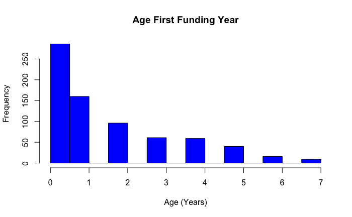

```r
hist(dataset$age_first_funding_year,
     main = "Age First Funding Year",
     xlab = "Age (Years)",
     ylab = "Frequency",
     col = "blue",
     border = "black")
```

The majority of startups secure their first funding within the company’s first year. However, the older the startup is, the less funding its expected to receive.

#### B) Relationship between Total Funding and Average Number of Participants

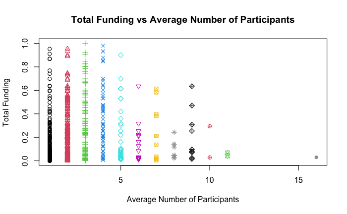

```r
with(dataset, plot(avg_participants, funding_total_usd, col = avg_participants, pch = as.numeric(avg_participants), main = "Total Funding vs Average Number of Participants",
     xlab = "Average Number of Participants",
     ylab = "Total Funding"))
```

The higher the average number of participants in a startup, the lesser the amount of funding received. This may suggest that startups with average number of participants less than 5 receive more funding than those higher than 5.

#### C) Distribution of Startup State of Origin

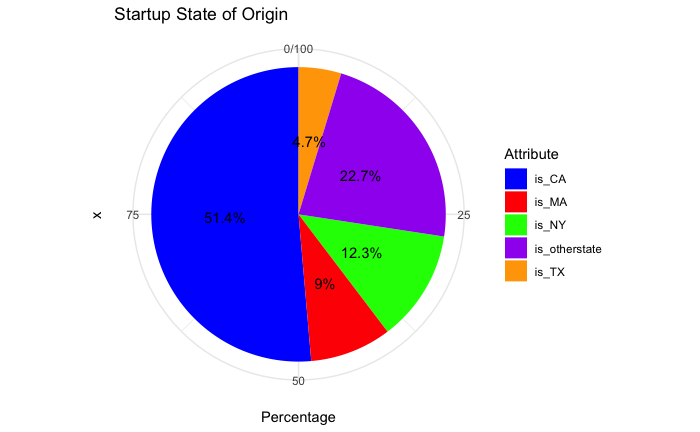

```r
library(ggplot2)

# Create a data frame with the counts of each binary attribute
binary_data <- data.frame(
  Attribute = c("is_CA", "is_NY", "is_MA", "is_TX", "is_otherstate"),
  Count = c(
    sum(dataset$is_CA),
    sum(dataset$is_NY),
    sum(dataset$is_MA),
    sum(dataset$is_TX),
    sum(dataset$is_otherstate)
  )
)

# Calculate percentages
binary_data$Percentage <- (binary_data$Count / sum(binary_data$Count)) * 100

# Create a pie chart
pie_chart <- ggplot(binary_data, aes(x = "", y = Percentage, fill = Attribute)) +
  geom_bar(stat = "identity", width = 1) +
  coord_polar(theta = "y") +  # Convert to polar coordinates for a pie chart
  labs(title = "Startup State of Origin") +
  scale_fill_manual(values = c("is_CA" = "blue", "is_NY" = "green", "is_MA" = "red", "is_TX" = "orange", "is_otherstate" = "purple")) +
  theme_minimal() +  # Use a minimal theme
  geom_text(aes(label = paste0(round(Percentage, 1), "%")), position = position_stack(vjust = 0.5))

# Display the pie chart
print(pie_chart)
```

As depicted, the 51.4% of all startups originate from California. Representing the majority.

#### D) Distribution of Startup Sectors

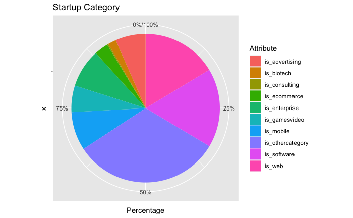

```r
library(ggplot2)
library(scales)

# Create a data frame for your binary attributes
binary_data <- data.frame(
  Attribute = c("is_software", "is_web", "is_mobile", "is_enterprise", "is_advertising", "is_gamesvideo", "is_ecommerce", "is_biotech", "is_consulting", "is_othercategory"),
  Value = c(sum(dataset$is_software), sum(dataset$is_web), sum(dataset$is_mobile), sum(dataset$is_enterprise), sum(dataset$is_advertising), sum(dataset$is_gamesvideo), sum(dataset$is_ecommerce), sum(dataset$is_biotech), sum(dataset$is_consulting), sum(dataset$is_othercategory))
)

# Calculate percentages
binary_data$Percentage <- (binary_data$Value / sum(binary_data$Value)) * 100

# Create the pie chart
pie_chart <- ggplot(binary_data, aes(x = "", y = Percentage, fill = Attribute)) +
  geom_bar(stat = "identity") +
  coord_polar(theta = "y") +
  labs(title = "Startup Category") +
  scale_y_continuous(labels = percent_format(scale = 1))

# Display the pie chart
print(pie_chart)
```

#### E) Relationship between Different Funding Rounds and ‘Acquired’ Status

```r
var(dataset$has_VC)
```

```
[1] 0.2057021
```

```r
var(dataset$has_angel)
```

```
[1] 0.2045312
```

```r
var(dataset$has_roundA)
```

```
[1] 0.2503401
```

```r
var(dataset$has_roundB)
```

```
[1] 0.2237392
```

```r
var(dataset$has_roundC)
```

```
[1] 0.1425724
```

```r
var(dataset$has_roundD)
```

```
[1] 0.04588842
```

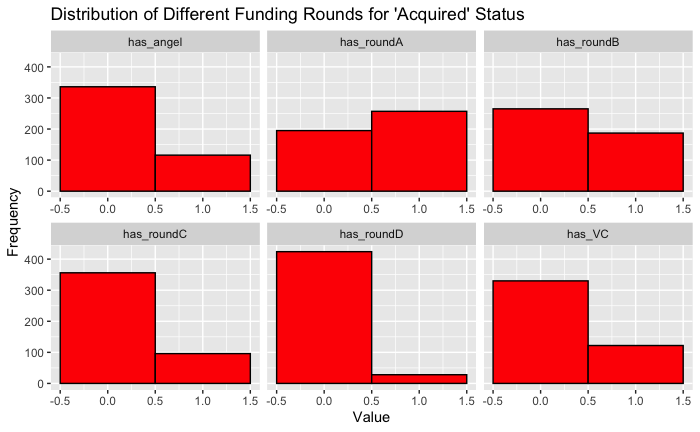

```r
library(ggplot2)

# Filter rows where status is "acquired"
acquired_data <- subset(dataset, status == "acquired")

# Create a long-format dataset for use with ggplot2
library(tidyr)
acquired_data_long <- gather(acquired_data, key = "Attribute", value = "BinaryValue", has_VC, has_angel, has_roundA, has_roundB, has_roundC, has_roundD)

# Create histograms with facet_wrap
ggplot(acquired_data_long, aes(x = BinaryValue)) +
  geom_histogram(binwidth = 1, fill = "red", color = "black") +
  facet_wrap(~ Attribute, scales = "free_x") +
  labs(title = "Distribution of Different Funding Rounds for 'Acquired' Status",
       x = "Value",
       y = "Frequency")
```

#### F) Relationship between Different Funding Rounds and ‘Closed’ Status

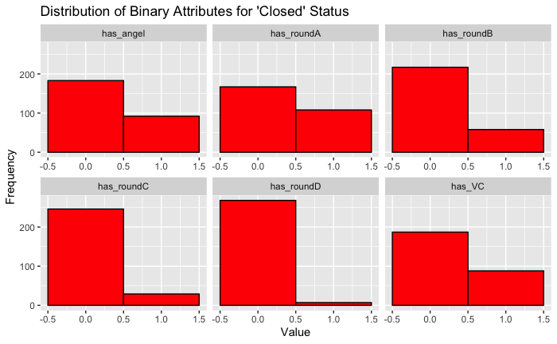

```r
library(ggplot2)

# Filter rows where status is "closed"
closed_data <- subset(dataset, status == "closed")

# Create a long-format dataset for use with ggplot2
library(tidyr)
closed_data_long <- gather(closed_data, key = "Attribute", value = "BinaryValue", has_VC, has_angel, has_roundA, has_roundB, has_roundC, has_roundD)

# Create histograms with facet_wrap
ggplot(closed_data_long, aes(x = BinaryValue)) +
  geom_histogram(binwidth = 1, fill = "red", color = "black") +
  facet_wrap(~ Attribute, scales = "free_x") +
  labs(title = "Distribution of Binary Attributes for 'Closed' Status",
       x = "Value",
       y = "Frequency")
```

As illustrated, the majority of “closed” startups did not have an angel or VC investors, series A, series B, series C or series D funding rounds.

The majority of “acquired” startups had a series A funding round, while the majority of “closed” startups did not. Series A and Series B funding could be a potential indicator of startup success.

Angel investors invested almost equally in both “acquired” and “closed” startups.

VCs tend to invest more in startups that become “acquired” in the future.

#### G) Relationship between the Number of Funding Rounds and Total Funding Raised

```r
range(dataset$funding_total_usd)
```

```
[1] 0 1
```

The least amount of funding invested in a startup was 11000 USD. The most (max) amount of funding invested in a startup after normalization and removing outliers was 47218498 USD.

```r
quantile(dataset$funding_total_usd)
```

```
        0%        25%        50%        75%       100%
0.00000000 0.04213314 0.14804852 0.32878878 1.00000000
```

```r
range(dataset$funding_rounds)
```

```
[1] 1 6
```

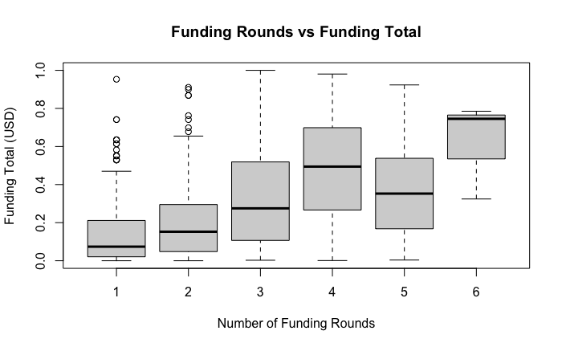

```r
boxplot(dataset$funding_total_usd ~ dataset$funding_rounds,
        xlab = "Number of Funding Rounds",
        ylab = "Funding Total (USD)",
        main = "Funding Rounds vs Funding Total")
```

#### H) Relationship between Total Funding and Startup Category

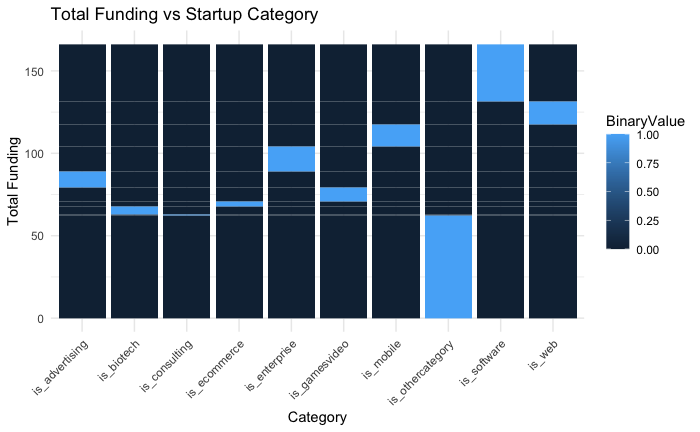

```r
library(ggplot2)
library(dplyr)
library(tidyr)

# Summary table: Sum of funding for each category
category_funding_summary <- dataset %>%
  group_by(is_software, is_web, is_mobile, is_enterprise,
           is_advertising, is_gamesvideo, is_ecommerce, is_biotech, is_consulting, is_othercategory) %>%
  summarise(total_funding = sum(funding_total_usd))
# Reshape the data for plotting
category_funding_summary <- category_funding_summary %>%
  pivot_longer(
    cols = -total_funding,
    names_to = "Category",
    values_to = "BinaryValue"
  )

# Create a bar plot
ggplot(category_funding_summary, aes(x = Category, y = total_funding, fill = BinaryValue)) +
  geom_bar(stat = "identity") +
  labs(title = "Total Funding vs Startup Category", x = "Category", y = "Total Funding") +
  theme_minimal() +
  theme(axis.text.x = element_text(angle = 45, hjust = 1))
```

#### I) Relationship between Top 500 Companies and Status

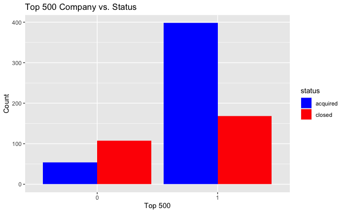

```r
library(ggplot2)

# Create a summary table to count the combinations of is_top500 and status
summary_table <- table(dataset$is_top500, dataset$status)

# Convert the summary table to a data frame
summary_df <- as.data.frame(summary_table)

# Rename the columns for clarity
colnames(summary_df) <- c("is_top500", "status", "count")

# Create a barplot
ggplot(summary_df, aes(x = is_top500, y = count, fill = status)) +
  geom_bar(stat = "identity", position = "dodge") +
  labs(title = "Top 500 Company vs. Status",
       x = "Top 500", y = "Count") +
  scale_fill_manual(values = c("acquired" = "blue", "closed" = "red"))
```

#### J) Heatmap

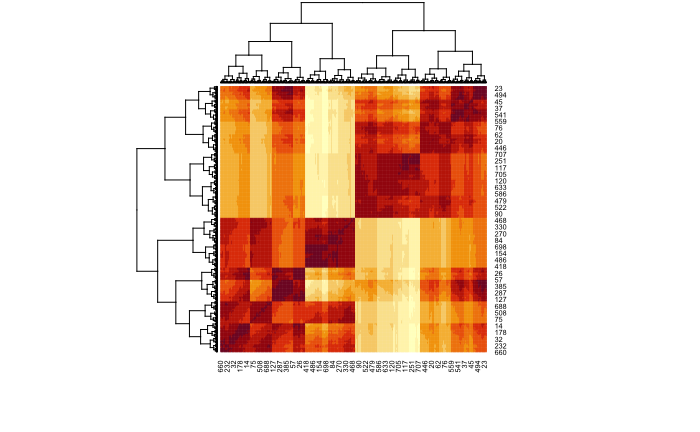

```r
dist.matrix <-- as.matrix(dist(dataset[1:10]))
heatmap(dist.matrix)
```